```python
import requests
import time
import pandas as pd
import numpy as np
from multiprocessing import Pool
```

# MTG: Best booster box to buy

In this notebook we are going to show a statistical test that calculates the expected revenue obtained from a given box of booster for different sets of *Magic the Gathering*. Here is the problem: Suppose that we buy a box of booster to sell the cards separately, afterwards. However, we only have one shot, I mean, we can only buy one box of booster, and there are several sets of expansions that we can choose to buy the box. That means that we need to pick the one with highest ROI, we need to *choose wisely*:

[figure not shown]

Therefore, we are going to calculate the expected value obtained from a box of boosters. Then we will compare all the sets of expansions, and pick the one with highest expected revenue per card.

Well, first of all we need to gather all the information about the cards. For that purpose, we are going to use [Scryfall API](https://scryfall.com/docs/api), which gives us a thorough description of every card in each set. In particular, we are going to focus on the card's name, the rarity, the set and, of course, the price. Finally, the only sets we are going to focus on are the last 6 sets of *Stardard* version, since they are the ones that can be best sold in the future (they will still be Standard next year as well).

```python
sets = "m19 xln hou akh rix dom".split()
cards = list()

for s in sets:
    has_more = True
    next_page = 'https://api.scryfall.com/cards/search?q=set%3A'+s
    while has_more:
        try:
            res = requests.get(next_page)
            result = res.json()

            card_batch = [(card['name'], card['eur'] if 'eur' in card else None, card['rarity'], card['set']) for card in result['data']]
            cards.extend(card_batch)
            has_more = result['has_more']
            if has_more:
                next_page = result['next_page']

            time.sleep(1)
        except Exception as e:
            has_more = False
```

After gathering all the information, we can create a DataFrame, so that it is easier to handle all the data.

```python
cards_df = pd.DataFrame(cards, columns=['name', 'price', 'rarity', 'set'])
cards_df['rarity_norm'] = cards_df['rarity'].apply(lambda r: 'rare' if r=='mythic' else r)

cards_df.head()
```

|  | name | price | rarity | set | rarity_norm |
| --- | --- | --- | --- | --- | --- |
| 0 | Abnormal Endurance | 0.04 | common | m19 | common |
| 1 | Act of Treason | 0.03 | common | m19 | common |
| 2 | Aegis of the Heavens | 0.07 | uncommon | m19 | uncommon |
| 3 | Aerial Engineer | 0.05 | uncommon | m19 | uncommon |
| 4 | Aethershield Artificer | 0.06 | uncommon | m19 | uncommon |

Seems perfect so far. Now we are going to move to the part where we calculate the expected revenue obtained by selling each card separately. Specifically, we are going to sample among every type of card (*common*, *uncommon*, and *rare*).

### Sampling

```python
s, total = 'xln', totals.loc['xln']
n_samples = 1000 # Total number of samples to be run
n_cards = {'common':12, 'uncommon':2, 'rare':1} # Total number of cards per rarity in each booster
n_boosters = 36 # Boosters per box

def sample_booster_price(set_df, rarity, n):
    rarity_df = set_df[set_df['rarity']==rarity]
    return rarity_df.iloc[np.random.randint(0, rarity_df.shape[0], size=n)]['price'].astype(float).sum()

def sample_set(set_):
    # First we obtain the dataframe for the analyzed set
    set_df = cards_df[cards_df['set']==set_]

    quants = [pd.DataFrame([{rarity: sample_booster_price(set_df, rarity, size)
                              for rarity, size in n_cards.iteritems()}
                            for _ in range(n_boosters)]).sum().to_dict()
              for _ in range(n_samples)]

    return pd.DataFrame(quants)

p = Pool(6)
prices_per_set = p.map(sample_set, sets)
p.close()
```

```python
for s, quants in zip(sets, prices_per_set):
    quants['total'] = quants.sum(1)
    print s
    print "===="
    print quants.describe()
    print "\n"
```

```
m19
====
            common         rare     uncommon        total
count  1000.000000  1000.000000  1000.000000  1000.000000
mean     19.610020    21.431980     6.113170    47.155170
std       1.355037     4.298312     0.527112     4.525472
min      16.080000    11.160000     4.860000    36.900000
25%      18.677500    18.240000     5.750000    43.805000
50%      19.515000    21.215000     6.070000    46.835000
75%      20.500000    24.372500     6.422500    50.225000
max      24.530000    37.340000     8.240000    62.050000


xln
====
            common         rare     uncommon        total
count  1000.000000  1000.000000  1000.000000  1000.000000
mean     19.343100    46.175780    11.286240    76.805120
std       0.557095    14.164854     3.085911    14.420355
min      17.810000    16.320000     5.470000    47.170000
25%      18.947500    35.865000     8.945000    66.250000
50%      19.340000    44.380000    10.860000    75.055000
75%      19.720000    54.765000    13.122500    85.760000
max      21.030000   102.270000    23.560000   130.550000


hou
====
            common         rare    uncommon        total
count  1000.000000  1000.000000  1000.00000  1000.000000
mean     16.750420    22.549040     8.31739    47.616850
std       0.491201     4.089887     1.23888     4.246313
min      15.240000    11.320000     5.36000    36.050000
25%      16.457500    19.697500     7.44750    44.660000
50%      16.740000    22.140000     8.24500    47.500000
75%      17.062500    25.335000     9.04000    50.475000
max      18.340000    34.600000    13.91000    61.840000


akh
```

[output cut: 21 more lines]

```
75%      17.030000    39.11250     9.63000    64.672500
max      17.980000    68.42000    13.71000    96.120000


dom
====
            common         rare     uncommon       total
count  1000.000000  1000.000000  1000.000000  1000.00000
mean     19.759340    22.649750     8.217310    50.62640
std       0.553504     5.233865     1.185721     5.40916
min      18.050000     8.870000     5.810000    36.72000
25%      19.370000    18.757500     7.387500    46.70750
50%      19.770000    22.330000     7.990000    50.44000
75%      20.150000    26.200000     8.912500    53.99250
max      21.660000    40.580000    13.480000    68.11000
```

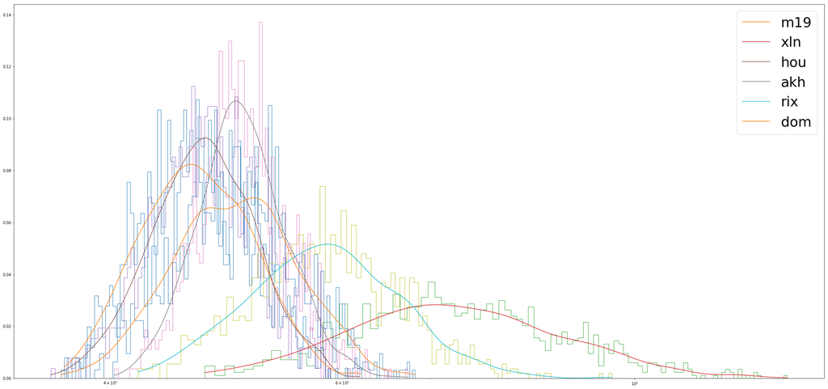

```python
from matplotlib import pyplot as plt
import scipy.stats as stats

quants_per_set = dict(zip(sets, prices_per_set))

plt.figure(figsize=(38,18))
for s in sets:
    noise = pd.DataFrame(quants_per_set[s])['total'].values
    density = stats.gaussian_kde(noise)

    n, x, _ = plt.hist(noise, bins=100,
                       histtype=u'step', normed=True)
    plt.plot(x, density(x))

plt.legend(sets, fontsize=36)
plt.xscale('log')
plt.show()
```

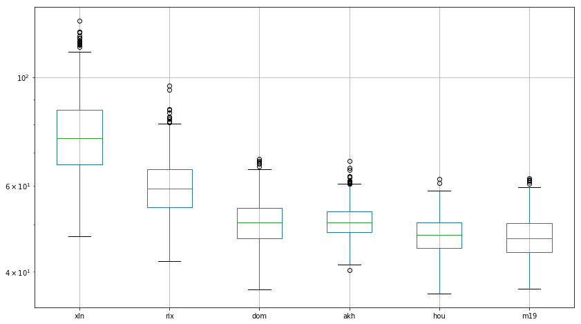

```python
dfs = list()

for s, quants in quants_per_set.iteritems():
    d = pd.DataFrame(quants)
    d[s] = d['total']
    dfs.append( d[s] )

plt.figure(figsize=(14, 8))
pd.concat(dfs, 1).boxplot()

plt.yscale('log')
plt.show()
```